# bak_lab5

Jakub Bąk

22 11 2020

# Zadania na piate laboratorium

Zadanie 1: Pobierz i wczytaj w RStudio plik z danymi Movie_classification.csv. Celem zadania jest przewidzenie, czy dany film otrzyma Oskara czy też nie (zmienna dychotomiczna Start_Tech_Oskar).

```r
drzewo <- read.csv("./data/Movie_classification.csv", sep=",", header=TRUE, nrow=510, dec = ".", na.strings = " ")
```

Zadanie 2: Przyglądnij się danym i przygotuj je do dalszej analizy

```r
drzewo$X3D_available <- as.factor(drzewo$X3D_available)
drzewo$Genre <- as.factor(drzewo$Genre)
library(dplyr)
drzewo %>%
  filter(!complete.cases(drzewo))
```

```
##    Marketing.expense Production.expense Multiplex.coverage   Budget
## 1            45.0358              71.28              0.462 30941.35
## 2            23.0890              65.26              0.547 34135.47
## 3            22.9864              65.26              0.547 31891.26
## 4            22.7920              72.12              0.480 34257.68
## 5            22.6524              72.12              0.480 32502.31
## 6            23.9604              76.18              0.511 34341.01
## 7            30.8022              62.94              0.353 40012.67
## 8           105.2262              91.20              0.230 33952.16
## 9           516.0340              91.20              0.307 29713.69
## 10          236.6840              91.20              0.321 37674.01
## 11          461.0220              91.20              0.260 32318.99
## 12           25.7920              74.38              0.415 29941.45
##    Movie_length Lead_.Actor_Rating Lead_Actress_rating Director_rating
## 1         171.6              8.035               8.205           7.955
```

[output cut: 50 more lines]

```r
mean_Time_taken <- mean(drzewo$Time_taken, na.rm=TRUE)
drzewo$Time_taken[is.na(drzewo$Time_taken)] <- mean_Time_taken

library(dummies)
new_drzewo <- dummy.data.frame(drzewo, names=c("X3D_available","Genre"))
```

Note: Zmienne “X3D_available” oraz “Genre” należy najpierw zmienic w typ faktor, aby móc dalej na nich pracowac, a nastepnie zamienic je za pomoca funkcji dummy w dane, na ktorych mozna predyktowac. Dodatkowo niekompletne dane sa filtrowane, aby zobaczyc automatycznie ktore dane sa niekompletne, a nastepnie w nich brakujace wartosci sa zastepowane wartosciami srednimi

Zadanie 3: Utwórz model drzewa klasyfikacyjnego na danych treningowych

```r
library(caTools)
drzewo_split <- sample.split(new_drzewo, SplitRatio = 2/3)
training_data <- subset(new_drzewo, drzewo_split == TRUE)
testing_data <- subset(new_drzewo, drzewo_split == FALSE)

library(rpart)
model <- rpart(training_data$Start_Tech_Oscar~., data=training_data, subset = c(sample(1:330, 330)))
```

Zadanie 4: Przedstaw graficznie utworzone drzewo (np. użyj funkcji rpart.plot)

[figure not shown]

```r
library(maptree)
draw.tree(model, cex=0.7, nodeinfo=TRUE)
```

Zadanie 5: Sprawdź działanie modelu na danych testowych. Wyniki predykcji zapisz w kolumnie pred w testowej ramce danych.

```r
pred <- predict(model, testing_data)
testing_data$pred <- pred
```

Zadanie 6: Sprawdź dokładność predykcji (utwórz tabelę liczności porównującą dane rzeczywiste z przewidywanymi przez model). Jaki procent danych został poprawnie zaklasyfikowany?

```r
for (i in 1:nrow(testing_data)){
  if (testing_data$pred[i] > 0.5) {
    testing_data$will_win[i] <- 1
  }
  else{
    testing_data$will_win[i] <- 0
  }
}

confusion_matrix <- table(testing_data$Start_Tech_Oscar,testing_data$will_win)
confusion_matrix
```

```
##
##      0  1
##   0 45 37
##   1 34 60
```

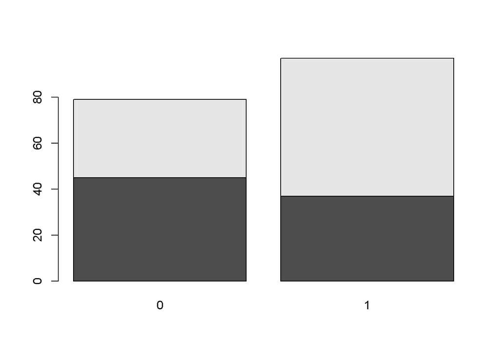

```r
barplot(confusion_matrix)
```

```r
model_accuracy <- sum(confusion_matrix[1,1],confusion_matrix[2,2])/sum(confusion_matrix[1,1],confusion_matrix[2,1],confusion_matrix[1,2],confusion_matrix[2,2])
model_accuracy*100
```

```
## [1] 59.65909
```

Note: W celu sprawdzenia dokladnosci predykcji wprowadzam zmienna “will_win”, ktora dla wartosci pred > 0.5 otrzymuje wartosc 1, a ponizej otrzymuje wartosc 0. Nastepnie tworze tabele licznosci, z ktorej nastepnie licze dokladnosc predykcji